# The spatial distribution and the spatial auto correlation of the house price (buying price) in the city of Buffalo

JunjieLi

## Introduction

1.Package: ggmap, rvest, ape

2.Data source:

- www.trulia.com (one of housing price website in the United States)
- Google Map API

3.The method of getting data:

- using the package(rvest) to grab the house data from the www.trulia.com, because it will take a long time if you get the record from the website by inputting to the table by yourself. So the package(rvest) is a good choice to get the data in the HTML file by identifying the CSS selectors where the data stores in. From the www.trulia.com, I want to get the attributes about the address, price, and the coordinates. The address and the price can get from the HTML page directly by the package. But the coordinates in the website are also from the Google map API, in order to get the coordinates of houses, I use the function geocode()* from the package(ggmap). Inputting the address name into the function geocode(), and the function will send the requires to the Google map API, and then download the coordinates(lon,lat) of the address automatically. Eventually, joining the columns of address, price, lon and lat together to build the final data table(Buffalo_House_Price).
- Keeping the same coordinate system between Buffalo_House_Price table and the boundary of Buffalo city. Plotting the house price distribution result(Not done yet).
4. Analyzing the spatial auto correlation of the house price by the package(ape) and calculate the Moran’s I by R(Not done yet).

[output not shown]

[output not shown]

[output not shown]

[output not shown]

[output not shown]

[output not shown]

[output not shown]

[output not shown]

[output not shown]

[output not shown]

[output not shown]

[output not shown]

[output not shown]

[output not shown]

[output not shown]

[output not shown]

[output not shown]

[output not shown]

[output not shown]

[output not shown]

[output not shown]

[output not shown]

[output not shown]

[output not shown]

[output not shown]

[output not shown]

[output not shown]

[output not shown]

[output not shown]

```
##                                              Name      price       lon
## 1        112 Carmel RdStarin Central, Buffalo, NY   $189,900 -78.83801
## 2           519 Woodlawn AveKingsley, Buffalo, NY    $29,900 -78.84557
## 3         1059 Parker BlvdKenilworth, Buffalo, NY   $138,900 -78.83800
## 4           178 Albany StGrant Ferry, Buffalo, NY   $154,900 -78.89505
## 5      337 Crowley AveRiverside Park, Buffalo, NY    $59,000        NA
## 6                     103 Parkside CirBuffalo, NY    $30,000 -78.85168
## 7          418 Dearborn StBlack Rock, Buffalo, NY    $49,900 -78.90438
## 8  70 Harmonia StBroadway - Fillmore, Buffalo, NY     $9,000 -78.83099
## 9       19 Nottingham TerPark Meadow, Buffalo, NY $1,045,000        NA
## 10           234 Riley StMasten Park, Buffalo, NY    $10,000 -78.85765
## 11                3473 S Park Ave #A18Buffalo, NY    $11,900 -78.82527
## 12        149 Arkansas StGrant Ferry, Buffalo, NY    $49,900        NA
## 13             230 Potomac AveForest, Buffalo, NY    $58,800        NA
## 14             388 Bristol StBabcock, Buffalo, NY    $39,900 -78.84203
```

[output cut: 167 more lines]

## Including Plots

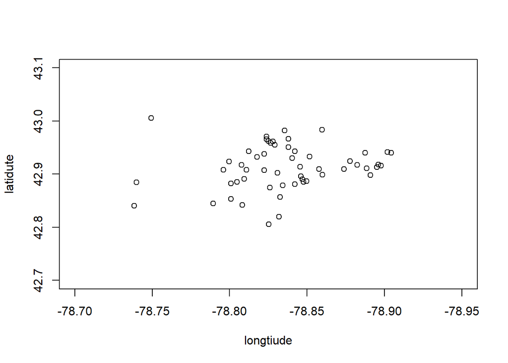